# Risk Factor Analysis

## Outcome Variable

**Outcome Variable:** y_rate_haz

## Predictor Variables

**Intervention Variable:** predfeed36

**Adjustment Set:**

unadjusted

## Stratifying Variables

The analysis was stratified on these variable(s):

- agecat
- studyid
- country

## Data Summary

| agecat | studyid | country | predfeed36 | n_cell | n |
| --- | --- | --- | --- | --- | --- |
| 0-3 months | ki0047075b-MAL-ED | BANGLADESH | 0 | 115 | 242 |
| 0-3 months | ki0047075b-MAL-ED | BANGLADESH | 1 | 127 | 242 |
| 0-3 months | ki0047075b-MAL-ED | BRAZIL | 0 | 151 | 180 |
| 0-3 months | ki0047075b-MAL-ED | BRAZIL | 1 | 29 | 180 |
| 0-3 months | ki0047075b-MAL-ED | INDIA | 0 | 184 | 200 |
| 0-3 months | ki0047075b-MAL-ED | INDIA | 1 | 16 | 200 |
| 0-3 months | ki0047075b-MAL-ED | NEPAL | 0 | 148 | 175 |
| 0-3 months | ki0047075b-MAL-ED | NEPAL | 1 | 27 | 175 |
| 0-3 months | ki0047075b-MAL-ED | PERU | 0 | 149 | 269 |
| 0-3 months | ki0047075b-MAL-ED | PERU | 1 | 120 | 269 |
| 0-3 months | ki0047075b-MAL-ED | SOUTH AFRICA | 0 | 226 | 229 |
| 0-3 months | ki0047075b-MAL-ED | SOUTH AFRICA | 1 | 3 | 229 |
| 0-3 months | ki0047075b-MAL-ED | TANZANIA, UNITED REPUBLIC OF | 0 | 228 | 229 |
| 0-3 months | ki0047075b-MAL-ED | TANZANIA, UNITED REPUBLIC OF | 1 | 1 | 229 |
| 0-3 months | ki1000109-EE | PAKISTAN | 0 | 252 | 594 |
| 0-3 months | ki1000109-EE | PAKISTAN | 1 | 342 | 594 |
| 0-3 months | kiGH5241-JiVitA-3 | BANGLADESH | 0 | 5998 | 30184 |
| 0-3 months | kiGH5241-JiVitA-3 | BANGLADESH | 1 | 24186 | 30184 |
| 0-3 months | kiGH5241-JiVitA-4 | BANGLADESH | 0 | 566 | 3370 |
| 0-3 months | kiGH5241-JiVitA-4 | BANGLADESH | 1 | 2804 | 3370 |
| 3-6 months | ki0047075b-MAL-ED | BANGLADESH | 0 | 107 | 230 |
| 3-6 months | ki0047075b-MAL-ED | BANGLADESH | 1 | 123 | 230 |
| 3-6 months | ki0047075b-MAL-ED | BRAZIL | 0 | 171 | 208 |
| 3-6 months | ki0047075b-MAL-ED | BRAZIL | 1 | 37 | 208 |
| 3-6 months | ki0047075b-MAL-ED | INDIA | 0 | 210 | 229 |
| 3-6 months | ki0047075b-MAL-ED | INDIA | 1 | 19 | 229 |
| 3-6 months | ki0047075b-MAL-ED | NEPAL | 0 | 202 | 233 |
| 3-6 months | ki0047075b-MAL-ED | NEPAL | 1 | 31 | 233 |
| 3-6 months | ki0047075b-MAL-ED | PERU | 0 | 142 | 266 |
| 3-6 months | ki0047075b-MAL-ED | PERU | 1 | 124 | 266 |

[output cut: 60 more lines]

The following strata were considered:

- agecat: 0-3 months, studyid: ki0047075b-MAL-ED, country: BANGLADESH
- agecat: 0-3 months, studyid: ki0047075b-MAL-ED, country: BRAZIL
- agecat: 0-3 months, studyid: ki0047075b-MAL-ED, country: INDIA
- agecat: 0-3 months, studyid: ki0047075b-MAL-ED, country: NEPAL
- agecat: 0-3 months, studyid: ki0047075b-MAL-ED, country: PERU
- agecat: 0-3 months, studyid: ki0047075b-MAL-ED, country: SOUTH AFRICA
- agecat: 0-3 months, studyid: ki0047075b-MAL-ED, country: TANZANIA, UNITED REPUBLIC OF
- agecat: 0-3 months, studyid: ki1000109-EE, country: PAKISTAN
- agecat: 0-3 months, studyid: kiGH5241-JiVitA-3, country: BANGLADESH
- agecat: 0-3 months, studyid: kiGH5241-JiVitA-4, country: BANGLADESH
- agecat: 12-24 months, studyid: ki0047075b-MAL-ED, country: BANGLADESH
- agecat: 12-24 months, studyid: ki0047075b-MAL-ED, country: BRAZIL
- agecat: 12-24 months, studyid: ki0047075b-MAL-ED, country: INDIA
- agecat: 12-24 months, studyid: ki0047075b-MAL-ED, country: NEPAL
- agecat: 12-24 months, studyid: ki0047075b-MAL-ED, country: PERU
- agecat: 12-24 months, studyid: ki0047075b-MAL-ED, country: SOUTH AFRICA
- agecat: 12-24 months, studyid: ki0047075b-MAL-ED, country: TANZANIA, UNITED REPUBLIC OF
- agecat: 12-24 months, studyid: ki1113344-GMS-Nepal, country: NEPAL
- agecat: 12-24 months, studyid: ki1148112-LCNI-5, country: MALAWI
- agecat: 12-24 months, studyid: kiGH5241-JiVitA-3, country: BANGLADESH
- agecat: 12-24 months, studyid: kiGH5241-JiVitA-4, country: BANGLADESH
- agecat: 3-6 months, studyid: ki0047075b-MAL-ED, country: BANGLADESH
- agecat: 3-6 months, studyid: ki0047075b-MAL-ED, country: BRAZIL
- agecat: 3-6 months, studyid: ki0047075b-MAL-ED, country: INDIA
- agecat: 3-6 months, studyid: ki0047075b-MAL-ED, country: NEPAL
- agecat: 3-6 months, studyid: ki0047075b-MAL-ED, country: PERU
- agecat: 3-6 months, studyid: ki0047075b-MAL-ED, country: SOUTH AFRICA
- agecat: 3-6 months, studyid: ki0047075b-MAL-ED, country: TANZANIA, UNITED REPUBLIC OF
- agecat: 3-6 months, studyid: ki1000109-EE, country: PAKISTAN
- agecat: 3-6 months, studyid: ki1113344-GMS-Nepal, country: NEPAL
- agecat: 3-6 months, studyid: kiGH5241-JiVitA-3, country: BANGLADESH
- agecat: 3-6 months, studyid: kiGH5241-JiVitA-4, country: BANGLADESH
- agecat: 6-12 months, studyid: ki0047075b-MAL-ED, country: BANGLADESH
- agecat: 6-12 months, studyid: ki0047075b-MAL-ED, country: BRAZIL
- agecat: 6-12 months, studyid: ki0047075b-MAL-ED, country: INDIA
- agecat: 6-12 months, studyid: ki0047075b-MAL-ED, country: NEPAL
- agecat: 6-12 months, studyid: ki0047075b-MAL-ED, country: PERU
- agecat: 6-12 months, studyid: ki0047075b-MAL-ED, country: SOUTH AFRICA
- agecat: 6-12 months, studyid: ki0047075b-MAL-ED, country: TANZANIA, UNITED REPUBLIC OF
- agecat: 6-12 months, studyid: ki1000109-EE, country: PAKISTAN
- agecat: 6-12 months, studyid: ki1000304b-SAS-FoodSuppl, country: INDIA
- agecat: 6-12 months, studyid: ki1113344-GMS-Nepal, country: NEPAL
- agecat: 6-12 months, studyid: ki1148112-LCNI-5, country: MALAWI
- agecat: 6-12 months, studyid: kiGH5241-JiVitA-3, country: BANGLADESH
- agecat: 6-12 months, studyid: kiGH5241-JiVitA-4, country: BANGLADESH

### Dropped Strata

Some strata were dropped due to rare outcomes:

- agecat: 0-3 months, studyid: ki0047075b-MAL-ED, country: SOUTH AFRICA
- agecat: 0-3 months, studyid: ki0047075b-MAL-ED, country: TANZANIA, UNITED REPUBLIC OF
- agecat: 3-6 months, studyid: ki0047075b-MAL-ED, country: SOUTH AFRICA
- agecat: 3-6 months, studyid: ki0047075b-MAL-ED, country: TANZANIA, UNITED REPUBLIC OF
- agecat: 6-12 months, studyid: ki0047075b-MAL-ED, country: SOUTH AFRICA
- agecat: 6-12 months, studyid: ki0047075b-MAL-ED, country: TANZANIA, UNITED REPUBLIC OF
- agecat: 6-12 months, studyid: ki1000109-EE, country: PAKISTAN
- agecat: 6-12 months, studyid: ki1000304b-SAS-FoodSuppl, country: INDIA
- agecat: 12-24 months, studyid: ki0047075b-MAL-ED, country: SOUTH AFRICA
- agecat: 12-24 months, studyid: ki0047075b-MAL-ED, country: TANZANIA, UNITED REPUBLIC OF

## Methods Detail

We’re interested in the causal parameters $E[Y_a]$ for all values of $a \in \mathcal{A}$. These parameters represent the mean outcome if, possibly contrary to fact, we intervened to set all units to have $A=a$. Under the randomization and positivity assumptions, these are identified by the statistical parameters $\psi_a=E_W[E_{Y|A,W}(Y|A=a,W)]$. In addition, we’re interested in the mean of $Y$, $E[Y]$ under no intervention (the observed mean). We will estimate these parameters by using SuperLearner to fit the relevant likelihood factors – $E_{Y|A,W}(Y|A=a,W)$ and $p(A=a|W)$, and then updating our likelihood fit using a joint TMLE.

For unadjusted analyses ($W=\{\}$), initial likelihoods were estimated using Lrnr_glm to estimate the simple $E(Y|A)$ and Lrnr_mean to estimate $p(A)$. For adjusted analyses, a small library containing Lrnr_glmnet, Lrnr_xgboost, and Lrnr_mean was used.

Having estimated these parameters, we will then use the delta method to estimate relative risks and attributable risks relative to a prespecified baseline level of $A$.

# Results Detail

## Results Plots

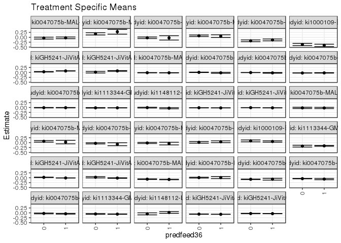

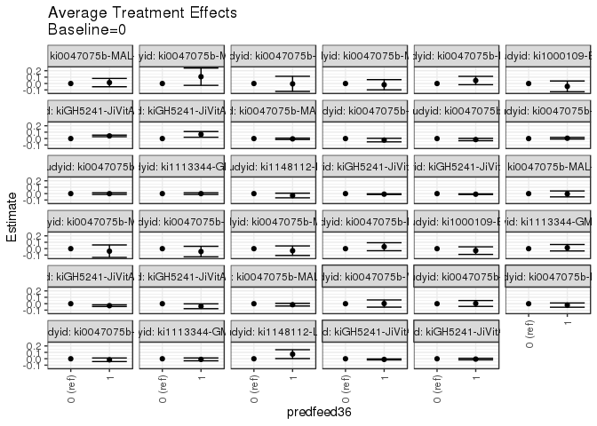

## Results Table

### Parameter: TSM

| agecat | studyid | country | intervention_level | baseline_level | estimate | ci_lower | ci_upper |
| --- | --- | --- | --- | --- | --- | --- | --- |
| 0-3 months | ki0047075b-MAL-ED | BANGLADESH | 0 | NA | -0.0419590 | -0.0897856 | 0.0058677 |
| 0-3 months | ki0047075b-MAL-ED | BANGLADESH | 1 | NA | -0.0272489 | -0.0709811 | 0.0164833 |
| 0-3 months | ki0047075b-MAL-ED | BRAZIL | 0 | NA | 0.1756933 | 0.1187922 | 0.2325945 |
| 0-3 months | ki0047075b-MAL-ED | BRAZIL | 1 | NA | 0.2822368 | 0.1599761 | 0.4044974 |
| 0-3 months | ki0047075b-MAL-ED | INDIA | 0 | NA | -0.0250300 | -0.0653710 | 0.0153111 |
| 0-3 months | ki0047075b-MAL-ED | INDIA | 1 | NA | -0.0302153 | -0.1410121 | 0.0805814 |
| 0-3 months | ki0047075b-MAL-ED | NEPAL | 0 | NA | 0.0775639 | 0.0380542 | 0.1170737 |
| 0-3 months | ki0047075b-MAL-ED | NEPAL | 1 | NA | 0.0584843 | -0.0107188 | 0.1276873 |
| 0-3 months | ki0047075b-MAL-ED | PERU | 0 | NA | -0.1793999 | -0.2245312 | -0.1342687 |
| 0-3 months | ki0047075b-MAL-ED | PERU | 1 | NA | -0.1327872 | -0.1798215 | -0.0857530 |
| 0-3 months | ki1000109-EE | PAKISTAN | 0 | NA | -0.3682845 | -0.4260295 | -0.3105395 |
| 0-3 months | ki1000109-EE | PAKISTAN | 1 | NA | -0.4126906 | -0.4730866 | -0.3522946 |
| 0-3 months | kiGH5241-JiVitA-3 | BANGLADESH | 0 | NA | 0.0319317 | 0.0201111 | 0.0437522 |
| 0-3 months | kiGH5241-JiVitA-3 | BANGLADESH | 1 | NA | 0.0734427 | 0.0674051 | 0.0794803 |
| 0-3 months | kiGH5241-JiVitA-4 | BANGLADESH | 0 | NA | 0.0098021 | -0.0317494 | 0.0513535 |
| 0-3 months | kiGH5241-JiVitA-4 | BANGLADESH | 1 | NA | 0.0752047 | 0.0590906 | 0.0913188 |
| 3-6 months | ki0047075b-MAL-ED | BANGLADESH | 0 | NA | -0.0187426 | -0.0523822 | 0.0148969 |
| 3-6 months | ki0047075b-MAL-ED | BANGLADESH | 1 | NA | -0.0234086 | -0.0551247 | 0.0083074 |
| 3-6 months | ki0047075b-MAL-ED | BRAZIL | 0 | NA | 0.0675009 | 0.0275094 | 0.1074924 |
| 3-6 months | ki0047075b-MAL-ED | BRAZIL | 1 | NA | 0.0280904 | -0.0605468 | 0.1167277 |
| 3-6 months | ki0047075b-MAL-ED | INDIA | 0 | NA | -0.0363736 | -0.0665165 | -0.0062307 |
| 3-6 months | ki0047075b-MAL-ED | INDIA | 1 | NA | -0.0815890 | -0.1577929 | -0.0053851 |
| 3-6 months | ki0047075b-MAL-ED | NEPAL | 0 | NA | -0.0172393 | -0.0459889 | 0.0115104 |
| 3-6 months | ki0047075b-MAL-ED | NEPAL | 1 | NA | -0.0489190 | -0.1177853 | 0.0199473 |
| 3-6 months | ki0047075b-MAL-ED | PERU | 0 | NA | 0.0140097 | -0.0288141 | 0.0568336 |
| 3-6 months | ki0047075b-MAL-ED | PERU | 1 | NA | 0.0441390 | -0.0009453 | 0.0892233 |
| 3-6 months | ki1000109-EE | PAKISTAN | 0 | NA | 0.0883633 | 0.0405627 | 0.1361640 |
| 3-6 months | ki1000109-EE | PAKISTAN | 1 | NA | 0.0580124 | 0.0235438 | 0.0924810 |
| 3-6 months | ki1113344-GMS-Nepal | NEPAL | 0 | NA | -0.1787657 | -0.2247591 | -0.1327723 |
| 3-6 months | ki1113344-GMS-Nepal | NEPAL | 1 | NA | -0.1642241 | -0.1848149 | -0.1436333 |
| 3-6 months | kiGH5241-JiVitA-3 | BANGLADESH | 0 | NA | 0.0194746 | 0.0072844 | 0.0316647 |
| 3-6 months | kiGH5241-JiVitA-3 | BANGLADESH | 1 | NA | -0.0111561 | -0.0170092 | -0.0053031 |
| 3-6 months | kiGH5241-JiVitA-4 | BANGLADESH | 0 | NA | 0.0240668 | -0.0100909 | 0.0582245 |
| 3-6 months | kiGH5241-JiVitA-4 | BANGLADESH | 1 | NA | -0.0156888 | -0.0309885 | -0.0003890 |
| 6-12 months | ki0047075b-MAL-ED | BANGLADESH | 0 | NA | -0.0726061 | -0.0879669 | -0.0572453 |
| 6-12 months | ki0047075b-MAL-ED | BANGLADESH | 1 | NA | -0.0878159 | -0.1018548 | -0.0737770 |
| 6-12 months | ki0047075b-MAL-ED | BRAZIL | 0 | NA | 0.0060922 | -0.0147716 | 0.0269560 |
| 6-12 months | ki0047075b-MAL-ED | BRAZIL | 1 | NA | 0.0087867 | -0.0433425 | 0.0609159 |
| 6-12 months | ki0047075b-MAL-ED | INDIA | 0 | NA | -0.0779771 | -0.0906696 | -0.0652846 |
| 6-12 months | ki0047075b-MAL-ED | INDIA | 1 | NA | -0.0741849 | -0.1178601 | -0.0305097 |
| 6-12 months | ki0047075b-MAL-ED | NEPAL | 0 | NA | -0.0460812 | -0.0573420 | -0.0348204 |
| 6-12 months | ki0047075b-MAL-ED | NEPAL | 1 | NA | -0.0677437 | -0.0992125 | -0.0362749 |
| 6-12 months | ki0047075b-MAL-ED | PERU | 0 | NA | -0.0298245 | -0.0506363 | -0.0090127 |
| 6-12 months | ki0047075b-MAL-ED | PERU | 1 | NA | -0.0455298 | -0.0640243 | -0.0270352 |
| 6-12 months | ki1113344-GMS-Nepal | NEPAL | 0 | NA | -0.0547249 | -0.0749464 | -0.0345035 |
| 6-12 months | ki1113344-GMS-Nepal | NEPAL | 1 | NA | -0.0645848 | -0.0736341 | -0.0555355 |
| 6-12 months | ki1148112-LCNI-5 | MALAWI | 0 | NA | -0.0513798 | -0.1030379 | 0.0002783 |
| 6-12 months | ki1148112-LCNI-5 | MALAWI | 1 | NA | 0.0202243 | -0.0261296 | 0.0665782 |
| 6-12 months | kiGH5241-JiVitA-3 | BANGLADESH | 0 | NA | -0.0636588 | -0.0706691 | -0.0566484 |
| 6-12 months | kiGH5241-JiVitA-3 | BANGLADESH | 1 | NA | -0.0741034 | -0.0773761 | -0.0708307 |
| 6-12 months | kiGH5241-JiVitA-4 | BANGLADESH | 0 | NA | -0.0347819 | -0.0456085 | -0.0239554 |
| 6-12 months | kiGH5241-JiVitA-4 | BANGLADESH | 1 | NA | -0.0397607 | -0.0450816 | -0.0344399 |
| 12-24 months | ki0047075b-MAL-ED | BANGLADESH | 0 | NA | -0.0152965 | -0.0237706 | -0.0068225 |
| 12-24 months | ki0047075b-MAL-ED | BANGLADESH | 1 | NA | -0.0196710 | -0.0266531 | -0.0126889 |
| 12-24 months | ki0047075b-MAL-ED | BRAZIL | 0 | NA | 0.0029597 | -0.0086191 | 0.0145385 |
| 12-24 months | ki0047075b-MAL-ED | BRAZIL | 1 | NA | -0.0204772 | -0.0455686 | 0.0046142 |
| 12-24 months | ki0047075b-MAL-ED | INDIA | 0 | NA | -0.0086568 | -0.0140022 | -0.0033115 |
| 12-24 months | ki0047075b-MAL-ED | INDIA | 1 | NA | -0.0239876 | -0.0411798 | -0.0067954 |
| 12-24 months | ki0047075b-MAL-ED | NEPAL | 0 | NA | -0.0301693 | -0.0356925 | -0.0246460 |
| 12-24 months | ki0047075b-MAL-ED | NEPAL | 1 | NA | -0.0250418 | -0.0370459 | -0.0130377 |
| 12-24 months | ki0047075b-MAL-ED | PERU | 0 | NA | -0.0090398 | -0.0195986 | 0.0015191 |
| 12-24 months | ki0047075b-MAL-ED | PERU | 1 | NA | -0.0095090 | -0.0184080 | -0.0006100 |
| 12-24 months | ki1113344-GMS-Nepal | NEPAL | 0 | NA | -0.0169971 | -0.0297496 | -0.0042445 |
| 12-24 months | ki1113344-GMS-Nepal | NEPAL | 1 | NA | -0.0170969 | -0.0227222 | -0.0114717 |
| 12-24 months | ki1148112-LCNI-5 | MALAWI | 0 | NA | -0.0053185 | -0.0263716 | 0.0157345 |
| 12-24 months | ki1148112-LCNI-5 | MALAWI | 1 | NA | -0.0345407 | -0.0639658 | -0.0051157 |
| 12-24 months | kiGH5241-JiVitA-3 | BANGLADESH | 0 | NA | -0.0127494 | -0.0175879 | -0.0079109 |
| 12-24 months | kiGH5241-JiVitA-3 | BANGLADESH | 1 | NA | -0.0210477 | -0.0232675 | -0.0188278 |
| 12-24 months | kiGH5241-JiVitA-4 | BANGLADESH | 0 | NA | -0.0075978 | -0.0119622 | -0.0032334 |
| 12-24 months | kiGH5241-JiVitA-4 | BANGLADESH | 1 | NA | -0.0167229 | -0.0189781 | -0.0144678 |

### Parameter: E(Y)

| agecat | studyid | country | intervention_level | baseline_level | estimate | ci_lower | ci_upper |
| --- | --- | --- | --- | --- | --- | --- | --- |
| 0-3 months | ki0047075b-MAL-ED | BANGLADESH | NA | NA | -0.0342392 | -0.0665521 | -0.0019264 |
| 0-3 months | ki0047075b-MAL-ED | BRAZIL | NA | NA | 0.1928587 | 0.1409027 | 0.2448147 |
| 0-3 months | ki0047075b-MAL-ED | INDIA | NA | NA | -0.0254448 | -0.0636028 | 0.0127132 |
| 0-3 months | ki0047075b-MAL-ED | NEPAL | NA | NA | 0.0746202 | 0.0395269 | 0.1097135 |
| 0-3 months | ki0047075b-MAL-ED | PERU | NA | NA | -0.1586062 | -0.1913606 | -0.1258518 |
| 0-3 months | ki1000109-EE | PAKISTAN | NA | NA | -0.3938516 | -0.4364614 | -0.3512419 |
| 0-3 months | kiGH5241-JiVitA-3 | BANGLADESH | NA | NA | 0.0651938 | 0.0595783 | 0.0708094 |
| 0-3 months | kiGH5241-JiVitA-4 | BANGLADESH | NA | NA | 0.0642202 | 0.0489852 | 0.0794552 |
| 3-6 months | ki0047075b-MAL-ED | BANGLADESH | NA | NA | -0.0212379 | -0.0443179 | 0.0018421 |
| 3-6 months | ki0047075b-MAL-ED | BRAZIL | NA | NA | 0.0604904 | 0.0239698 | 0.0970111 |
| 3-6 months | ki0047075b-MAL-ED | INDIA | NA | NA | -0.0401251 | -0.0685271 | -0.0117231 |
| 3-6 months | ki0047075b-MAL-ED | NEPAL | NA | NA | -0.0214542 | -0.0480456 | 0.0051373 |
| 3-6 months | ki0047075b-MAL-ED | PERU | NA | NA | 0.0280549 | -0.0030513 | 0.0591612 |
| 3-6 months | ki1000109-EE | PAKISTAN | NA | NA | 0.0701161 | 0.0419135 | 0.0983187 |
| 3-6 months | ki1113344-GMS-Nepal | NEPAL | NA | NA | -0.1671388 | -0.1860153 | -0.1482623 |
| 3-6 months | kiGH5241-JiVitA-3 | BANGLADESH | NA | NA | -0.0050971 | -0.0104963 | 0.0003021 |
| 3-6 months | kiGH5241-JiVitA-4 | BANGLADESH | NA | NA | -0.0093314 | -0.0232659 | 0.0046030 |
| 6-12 months | ki0047075b-MAL-ED | BANGLADESH | NA | NA | -0.0808013 | -0.0912137 | -0.0703889 |
| 6-12 months | ki0047075b-MAL-ED | BRAZIL | NA | NA | 0.0065644 | -0.0129183 | 0.0260472 |
| 6-12 months | ki0047075b-MAL-ED | INDIA | NA | NA | -0.0776724 | -0.0898619 | -0.0654829 |
| 6-12 months | ki0047075b-MAL-ED | NEPAL | NA | NA | -0.0488126 | -0.0594641 | -0.0381610 |
| 6-12 months | ki0047075b-MAL-ED | PERU | NA | NA | -0.0373127 | -0.0513600 | -0.0232653 |
| 6-12 months | ki1113344-GMS-Nepal | NEPAL | NA | NA | -0.0626340 | -0.0709302 | -0.0543379 |
| 6-12 months | ki1148112-LCNI-5 | MALAWI | NA | NA | -0.0281085 | -0.0675243 | 0.0113073 |
| 6-12 months | kiGH5241-JiVitA-3 | BANGLADESH | NA | NA | -0.0720156 | -0.0751021 | -0.0689290 |
| 6-12 months | kiGH5241-JiVitA-4 | BANGLADESH | NA | NA | -0.0387210 | -0.0435056 | -0.0339363 |
| 12-24 months | ki0047075b-MAL-ED | BANGLADESH | NA | NA | -0.0177078 | -0.0231267 | -0.0122889 |
| 12-24 months | ki0047075b-MAL-ED | BRAZIL | NA | NA | -0.0013016 | -0.0119070 | 0.0093038 |
| 12-24 months | ki0047075b-MAL-ED | INDIA | NA | NA | -0.0098833 | -0.0150187 | -0.0047479 |
| 12-24 months | ki0047075b-MAL-ED | NEPAL | NA | NA | -0.0295113 | -0.0345712 | -0.0244514 |
| 12-24 months | ki0047075b-MAL-ED | PERU | NA | NA | -0.0092560 | -0.0162726 | -0.0022393 |
| 12-24 months | ki1113344-GMS-Nepal | NEPAL | NA | NA | -0.0170788 | -0.0222320 | -0.0119257 |
| 12-24 months | ki1148112-LCNI-5 | MALAWI | NA | NA | -0.0140852 | -0.0319419 | 0.0037715 |
| 12-24 months | kiGH5241-JiVitA-3 | BANGLADESH | NA | NA | -0.0193591 | -0.0213957 | -0.0173226 |
| 12-24 months | kiGH5241-JiVitA-4 | BANGLADESH | NA | NA | -0.0147196 | -0.0167684 | -0.0126707 |

### Parameter: ATE

| agecat | studyid | country | intervention_level | baseline_level | estimate | ci_lower | ci_upper |
| --- | --- | --- | --- | --- | --- | --- | --- |
| 0-3 months | ki0047075b-MAL-ED | BANGLADESH | 0 | 0 | 0.0000000 | 0.0000000 | 0.0000000 |
| 0-3 months | ki0047075b-MAL-ED | BANGLADESH | 1 | 0 | 0.0147100 | -0.0500966 | 0.0795167 |
| 0-3 months | ki0047075b-MAL-ED | BRAZIL | 0 | 0 | 0.0000000 | 0.0000000 | 0.0000000 |
| 0-3 months | ki0047075b-MAL-ED | BRAZIL | 1 | 0 | 0.1065434 | -0.0283099 | 0.2413967 |
| 0-3 months | ki0047075b-MAL-ED | INDIA | 0 | 0 | 0.0000000 | 0.0000000 | 0.0000000 |
| 0-3 months | ki0047075b-MAL-ED | INDIA | 1 | 0 | -0.0051854 | -0.1230977 | 0.1127270 |
| 0-3 months | ki0047075b-MAL-ED | NEPAL | 0 | 0 | 0.0000000 | 0.0000000 | 0.0000000 |
| 0-3 months | ki0047075b-MAL-ED | NEPAL | 1 | 0 | -0.0190797 | -0.0987671 | 0.0606077 |
| 0-3 months | ki0047075b-MAL-ED | PERU | 0 | 0 | 0.0000000 | 0.0000000 | 0.0000000 |
| 0-3 months | ki0047075b-MAL-ED | PERU | 1 | 0 | 0.0466127 | -0.0185721 | 0.1117975 |
| 0-3 months | ki1000109-EE | PAKISTAN | 0 | 0 | 0.0000000 | 0.0000000 | 0.0000000 |
| 0-3 months | ki1000109-EE | PAKISTAN | 1 | 0 | -0.0444060 | -0.1279653 | 0.0391533 |
| 0-3 months | kiGH5241-JiVitA-3 | BANGLADESH | 0 | 0 | 0.0000000 | 0.0000000 | 0.0000000 |
| 0-3 months | kiGH5241-JiVitA-3 | BANGLADESH | 1 | 0 | 0.0415110 | 0.0288471 | 0.0541750 |
| 0-3 months | kiGH5241-JiVitA-4 | BANGLADESH | 0 | 0 | 0.0000000 | 0.0000000 | 0.0000000 |
| 0-3 months | kiGH5241-JiVitA-4 | BANGLADESH | 1 | 0 | 0.0654026 | 0.0208853 | 0.1099200 |
| 3-6 months | ki0047075b-MAL-ED | BANGLADESH | 0 | 0 | 0.0000000 | 0.0000000 | 0.0000000 |
| 3-6 months | ki0047075b-MAL-ED | BANGLADESH | 1 | 0 | -0.0046660 | -0.0508994 | 0.0415674 |
| 3-6 months | ki0047075b-MAL-ED | BRAZIL | 0 | 0 | 0.0000000 | 0.0000000 | 0.0000000 |
| 3-6 months | ki0047075b-MAL-ED | BRAZIL | 1 | 0 | -0.0394105 | -0.1366518 | 0.0578309 |
| 3-6 months | ki0047075b-MAL-ED | INDIA | 0 | 0 | 0.0000000 | 0.0000000 | 0.0000000 |
| 3-6 months | ki0047075b-MAL-ED | INDIA | 1 | 0 | -0.0452154 | -0.1271644 | 0.0367335 |
| 3-6 months | ki0047075b-MAL-ED | NEPAL | 0 | 0 | 0.0000000 | 0.0000000 | 0.0000000 |
| 3-6 months | ki0047075b-MAL-ED | NEPAL | 1 | 0 | -0.0316798 | -0.1063062 | 0.0429467 |
| 3-6 months | ki0047075b-MAL-ED | PERU | 0 | 0 | 0.0000000 | 0.0000000 | 0.0000000 |
| 3-6 months | ki0047075b-MAL-ED | PERU | 1 | 0 | 0.0301292 | -0.0320518 | 0.0923102 |
| 3-6 months | ki1000109-EE | PAKISTAN | 0 | 0 | 0.0000000 | 0.0000000 | 0.0000000 |
| 3-6 months | ki1000109-EE | PAKISTAN | 1 | 0 | -0.0303509 | -0.0892830 | 0.0285811 |
| 3-6 months | ki1113344-GMS-Nepal | NEPAL | 0 | 0 | 0.0000000 | 0.0000000 | 0.0000000 |
| 3-6 months | ki1113344-GMS-Nepal | NEPAL | 1 | 0 | 0.0145416 | -0.0358506 | 0.0649338 |
| 3-6 months | kiGH5241-JiVitA-3 | BANGLADESH | 0 | 0 | 0.0000000 | 0.0000000 | 0.0000000 |
| 3-6 months | kiGH5241-JiVitA-3 | BANGLADESH | 1 | 0 | -0.0306307 | -0.0438616 | -0.0173998 |
| 3-6 months | kiGH5241-JiVitA-4 | BANGLADESH | 0 | 0 | 0.0000000 | 0.0000000 | 0.0000000 |
| 3-6 months | kiGH5241-JiVitA-4 | BANGLADESH | 1 | 0 | -0.0397556 | -0.0773258 | -0.0021854 |
| 6-12 months | ki0047075b-MAL-ED | BANGLADESH | 0 | 0 | 0.0000000 | 0.0000000 | 0.0000000 |
| 6-12 months | ki0047075b-MAL-ED | BANGLADESH | 1 | 0 | -0.0152098 | -0.0360195 | 0.0055999 |
| 6-12 months | ki0047075b-MAL-ED | BRAZIL | 0 | 0 | 0.0000000 | 0.0000000 | 0.0000000 |
| 6-12 months | ki0047075b-MAL-ED | BRAZIL | 1 | 0 | 0.0026945 | -0.0534549 | 0.0588439 |
| 6-12 months | ki0047075b-MAL-ED | INDIA | 0 | 0 | 0.0000000 | 0.0000000 | 0.0000000 |
| 6-12 months | ki0047075b-MAL-ED | INDIA | 1 | 0 | 0.0037922 | -0.0416899 | 0.0492743 |
| 6-12 months | ki0047075b-MAL-ED | NEPAL | 0 | 0 | 0.0000000 | 0.0000000 | 0.0000000 |
| 6-12 months | ki0047075b-MAL-ED | NEPAL | 1 | 0 | -0.0216625 | -0.0550854 | 0.0117605 |
| 6-12 months | ki0047075b-MAL-ED | PERU | 0 | 0 | 0.0000000 | 0.0000000 | 0.0000000 |
| 6-12 months | ki0047075b-MAL-ED | PERU | 1 | 0 | -0.0157052 | -0.0435473 | 0.0121368 |
| 6-12 months | ki1113344-GMS-Nepal | NEPAL | 0 | 0 | 0.0000000 | 0.0000000 | 0.0000000 |
| 6-12 months | ki1113344-GMS-Nepal | NEPAL | 1 | 0 | -0.0098599 | -0.0320138 | 0.0122941 |
| 6-12 months | ki1148112-LCNI-5 | MALAWI | 0 | 0 | 0.0000000 | 0.0000000 | 0.0000000 |
| 6-12 months | ki1148112-LCNI-5 | MALAWI | 1 | 0 | 0.0716041 | 0.0021977 | 0.1410105 |
| 6-12 months | kiGH5241-JiVitA-3 | BANGLADESH | 0 | 0 | 0.0000000 | 0.0000000 | 0.0000000 |
| 6-12 months | kiGH5241-JiVitA-3 | BANGLADESH | 1 | 0 | -0.0104446 | -0.0179143 | -0.0029749 |
| 6-12 months | kiGH5241-JiVitA-4 | BANGLADESH | 0 | 0 | 0.0000000 | 0.0000000 | 0.0000000 |
| 6-12 months | kiGH5241-JiVitA-4 | BANGLADESH | 1 | 0 | -0.0049788 | -0.0170331 | 0.0070755 |
| 12-24 months | ki0047075b-MAL-ED | BANGLADESH | 0 | 0 | 0.0000000 | 0.0000000 | 0.0000000 |
| 12-24 months | ki0047075b-MAL-ED | BANGLADESH | 1 | 0 | -0.0043744 | -0.0153544 | 0.0066055 |
| 12-24 months | ki0047075b-MAL-ED | BRAZIL | 0 | 0 | 0.0000000 | 0.0000000 | 0.0000000 |
| 12-24 months | ki0047075b-MAL-ED | BRAZIL | 1 | 0 | -0.0234369 | -0.0510710 | 0.0041973 |
| 12-24 months | ki0047075b-MAL-ED | INDIA | 0 | 0 | 0.0000000 | 0.0000000 | 0.0000000 |
| 12-24 months | ki0047075b-MAL-ED | INDIA | 1 | 0 | -0.0153308 | -0.0333348 | 0.0026732 |
| 12-24 months | ki0047075b-MAL-ED | NEPAL | 0 | 0 | 0.0000000 | 0.0000000 | 0.0000000 |
| 12-24 months | ki0047075b-MAL-ED | NEPAL | 1 | 0 | 0.0051275 | -0.0080863 | 0.0183412 |
| 12-24 months | ki0047075b-MAL-ED | PERU | 0 | 0 | 0.0000000 | 0.0000000 | 0.0000000 |
| 12-24 months | ki0047075b-MAL-ED | PERU | 1 | 0 | -0.0004693 | -0.0142780 | 0.0133395 |
| 12-24 months | ki1113344-GMS-Nepal | NEPAL | 0 | 0 | 0.0000000 | 0.0000000 | 0.0000000 |
| 12-24 months | ki1113344-GMS-Nepal | NEPAL | 1 | 0 | -0.0000999 | -0.0140380 | 0.0138383 |
| 12-24 months | ki1148112-LCNI-5 | MALAWI | 0 | 0 | 0.0000000 | 0.0000000 | 0.0000000 |
| 12-24 months | ki1148112-LCNI-5 | MALAWI | 1 | 0 | -0.0292222 | -0.0654032 | 0.0069588 |
| 12-24 months | kiGH5241-JiVitA-3 | BANGLADESH | 0 | 0 | 0.0000000 | 0.0000000 | 0.0000000 |
| 12-24 months | kiGH5241-JiVitA-3 | BANGLADESH | 1 | 0 | -0.0082982 | -0.0135977 | -0.0029988 |
| 12-24 months | kiGH5241-JiVitA-4 | BANGLADESH | 0 | 0 | 0.0000000 | 0.0000000 | 0.0000000 |
| 12-24 months | kiGH5241-JiVitA-4 | BANGLADESH | 1 | 0 | -0.0091251 | -0.0139280 | -0.0043222 |